# Statistical Analysis of Ozone Layer Thickness

Anurag Dinesh Karmarkar

# Data Description

The ozone layer is a region in the Earth’s stratosphere which protects the Earth from the harmful ultraviolet rays emitted by the sun. In the recent years, it has been observed that the thickness of the ozone layer is rapidly decreasing. It is of utmost importance that we prevent the ozone layer from getting thinner. The ozone layer thickness is measured in Dobson Units. The dataset contains the measure of the ozone thickness from 1927 to 2016.

# Problem Statement

There are 2 tasks in this problem statement. The first task is to analyse the provided data using various modelling techniques such as linear, quadratic, cyclic, seasonal and cosine and determine the best model to fit the data. We will then use the data to predict the dobson unit values for the next five years i.e from 2017 to 2021. The second task is to propose a set of ARIMA(p,d,q) models using various model specification techniques such as ACF-PACF, EACF, BIC.

# Importing the libraries required for the task

```r
library(TSA)
library(readr)
library(tseries)
```

# Importing the data

```r
ozonethickness_data <- read_csv("C:/Users/smart/OneDrive/Documents/Master of Data Science (RMIT)/Semester 3/Time Series Analysis/Assignments/Assignment 1/data1.csv", col_names = FALSE)
head(ozonethickness_data)
```

| X1 |
| --- |
| 1.3511844 |
| 0.7605324 |
| -1.2685573 |
| -1.4636872 |
| -0.9792030 |
| 1.5085675 |

| X1 <dbl> |  |  |  |  |
| --- | --- | --- | --- | --- |
| 1.3511844 |  |  |  |  |
| 0.7605324 |  |  |  |  |
| -1.2685573 |  |  |  |  |
| -1.4636872 |  |  |  |  |
| -0.9792030 |  |  |  |  |
| 1.5085675 |  |  |  |  |

6 rows

# Analysis of Time Series Data (Solution of Task 1)

```r
#Converting data to a time series object
rownames(ozonethickness_data) <- seq(from=1927, to=2016)
class(ozonethickness_data)
```

```
## [1] "spec_tbl_df" "tbl_df"      "tbl"         "data.frame"
```

```r
ozonethickness <- ts(as.vector(ozonethickness_data), start=1927, end=2016)
head(ozonethickness)
```

```
## [1]  1.3511844  0.7605324 -1.2685573 -1.4636872 -0.9792030  1.5085675
```

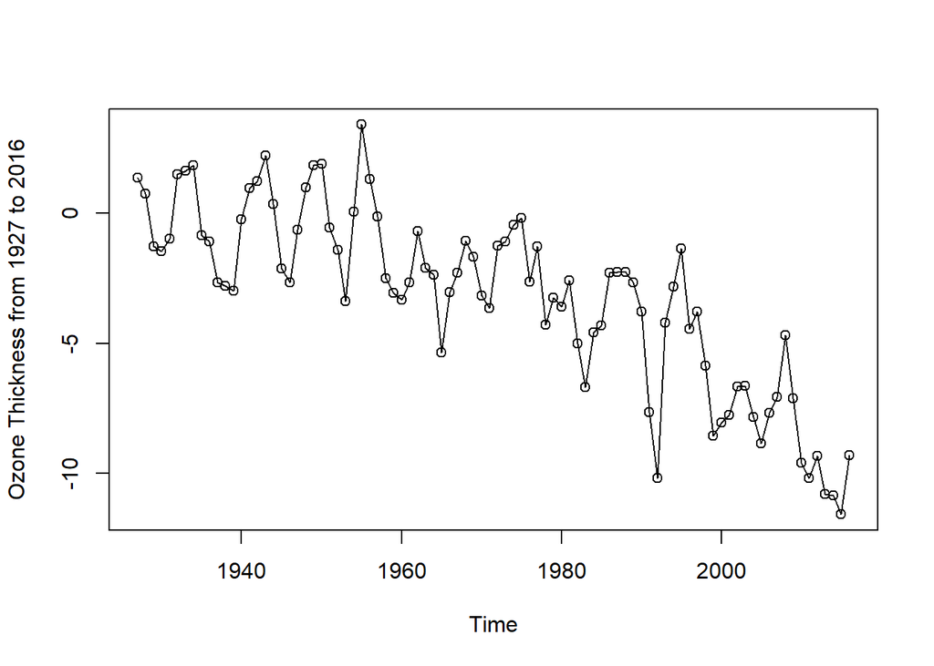

```r
#Plotting the time series data
plot(ozonethickness, type='o', ylab='Ozone Thickness from 1927 to 2016')
```

We have converted the data into a time series object and plotted the time series. We can observe that there is a negative trend in the series. The ozone layer has thinned drastically from 1980. The change from 1940 to 1960 is not drastic but gradual. The series appears to be non-cyclic, non-seasonal and non-stationary. However, we will check for these properties in the analysis.

## Creating a function for Residual Analysis

```r
residual_analysis <- function(model_used, timeseries) {
  res_model_used = rstudent(model_used)
  pt = plot(y = res_model_used,
            x = as.vector(time(timeseries)),
            xlab = 'Time',
            ylab='Standardized Residuals',
            type='l',
            main = "Standardised residuals from the model")
  abline(h=0)
  his = hist(res_model_used,xlab='Standardized Residuals', main = "Histogram of standardised residuals")
  qqn = qqnorm(y=res_model_used, main = "QQ plot of standardised residuals")
  qql = qqline(y=res_model_used, col = 2, lwd = 1, lty = 2)
  sha = shapiro.test(res_model_used)
  autocorr = acf(res_model_used, main = "ACF of standardized residuals")
  par_acf = pacf(res_model_used, main = "PACF of standardized residuals")
  return(his)
  return(qqn)
  return(qql)
  return(sha)
  return(autocorr)
  return(par_acf)
}
```

## Linear Model

```r
#Fitting the model
model_lm = lm(ozonethickness~time(ozonethickness))
summary(model_lm)
```

```
##
## Call:
## lm(formula = ozonethickness ~ time(ozonethickness))
##
## Residuals:
##     Min      1Q  Median      3Q     Max
## -4.7165 -1.6687  0.0275  1.4726  4.7940
##
## Coefficients:
##                        Estimate Std. Error t value Pr(>|t|)
## (Intercept)          213.720155  16.257158   13.15   <2e-16 ***
## time(ozonethickness)  -0.110029   0.008245  -13.34   <2e-16 ***
## ---
## Signif. codes:  0 '***' 0.001 '**' 0.01 '*' 0.05 '.' 0.1 ' ' 1
##
## Residual standard error: 2.032 on 88 degrees of freedom
## Multiple R-squared:  0.6693, Adjusted R-squared:  0.6655
## F-statistic: 178.1 on 1 and 88 DF,  p-value: < 2.2e-16
```

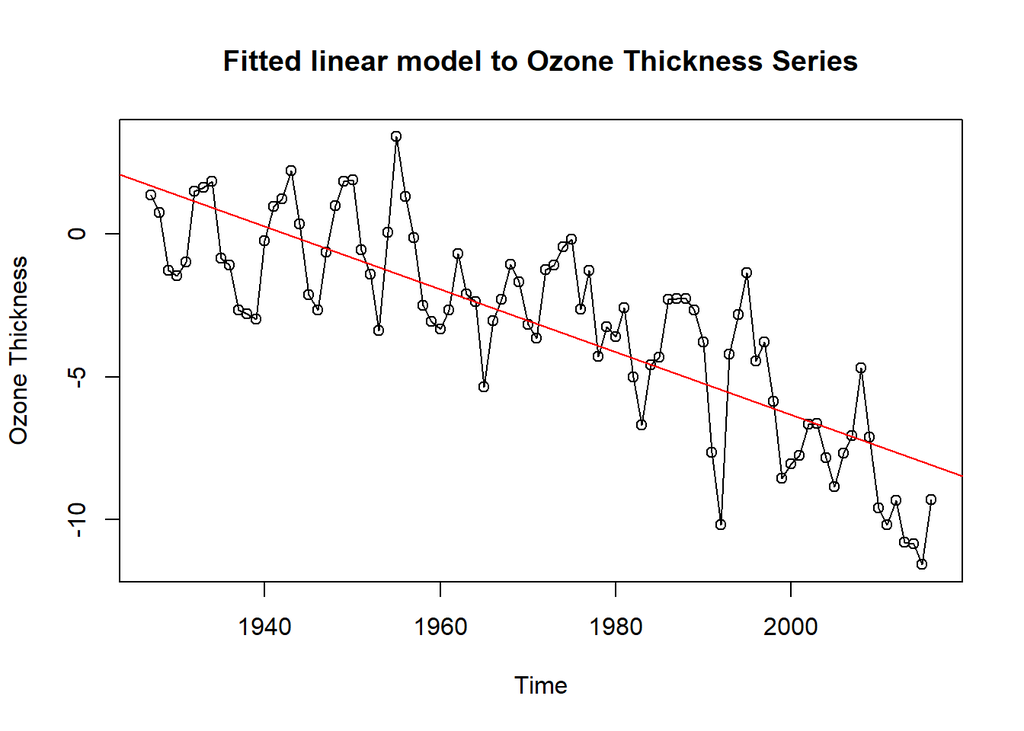

```r
#Plotting the fitted model
plot(ozonethickness,
     type='o',
     ylab='Ozone Thickness',
     main = "Fitted linear model to Ozone Thickness Series")
abline(model_lm, col = 'red')
```

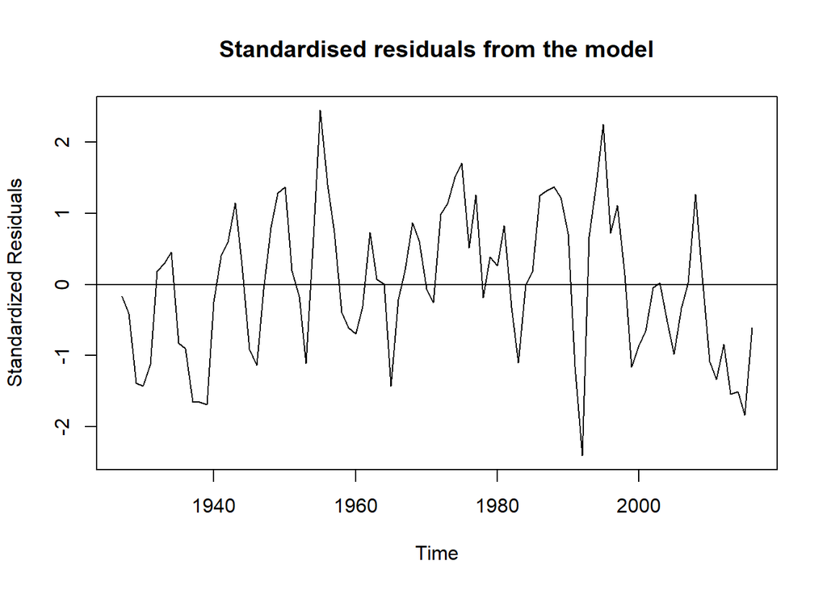

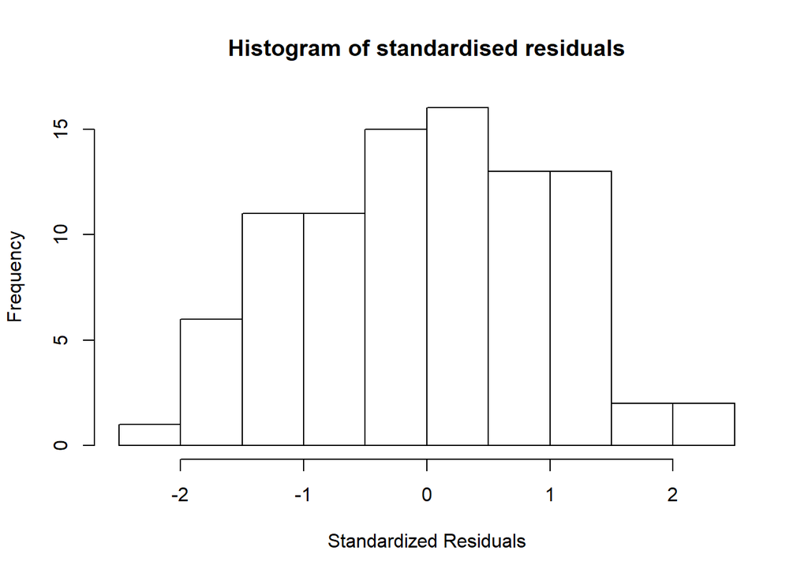

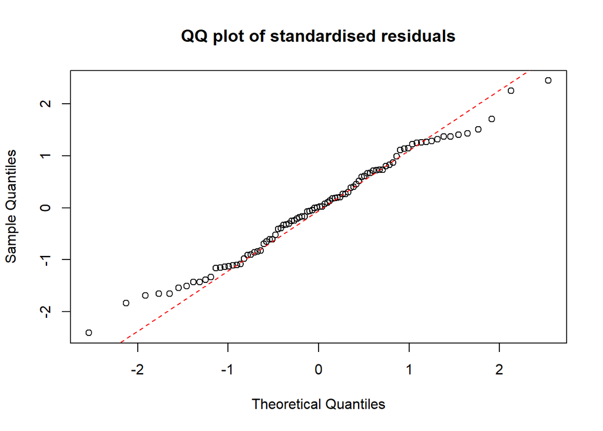

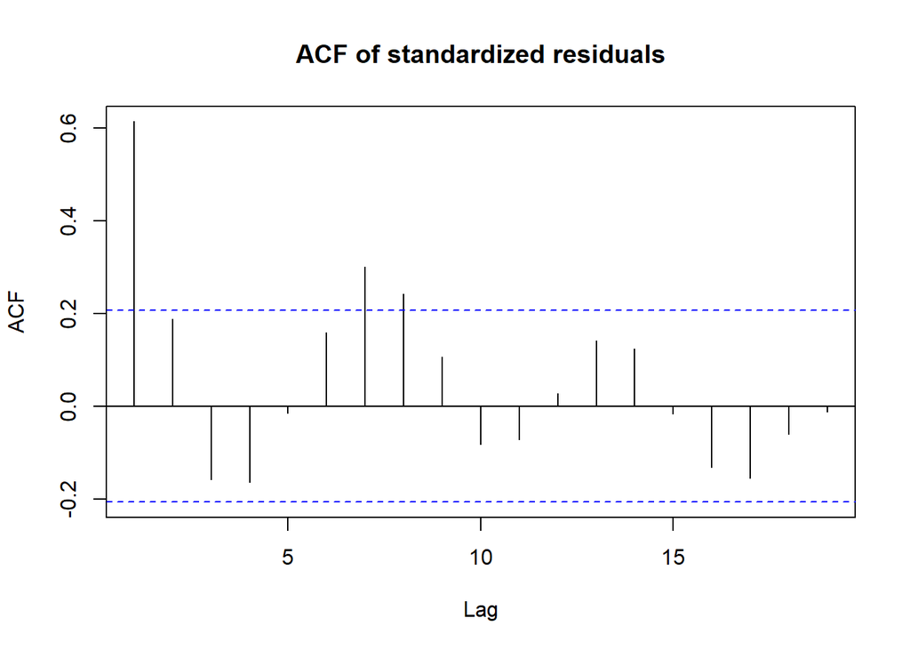

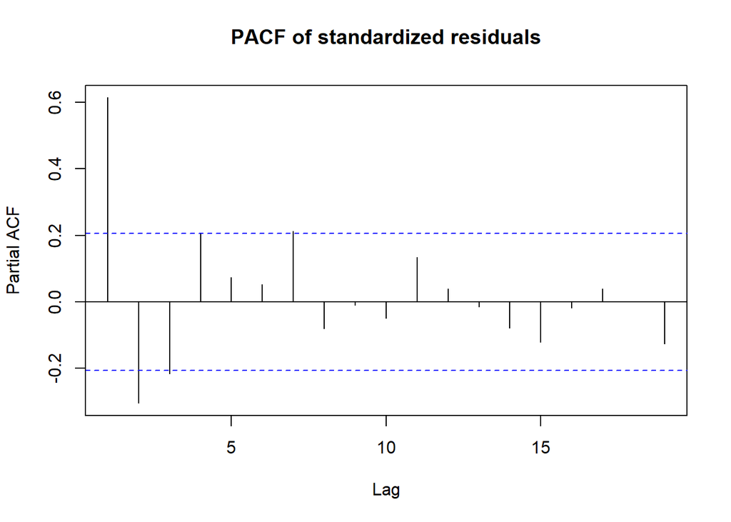

```
## $breaks
##  [1] -2.5 -2.0 -1.5 -1.0 -0.5  0.0  0.5  1.0  1.5  2.0  2.5
##
## $counts
##  [1]  1  6 11 11 15 16 13 13  2  2
##
## $density
##  [1] 0.02222222 0.13333333 0.24444444 0.24444444 0.33333333 0.35555556
##  [7] 0.28888889 0.28888889 0.04444444 0.04444444
##
## $mids
##  [1] -2.25 -1.75 -1.25 -0.75 -0.25  0.25  0.75  1.25  1.75  2.25
##
## $xname
## [1] "res_model_used"
##
## $equidist
## [1] TRUE
##
## attr(,"class")
## [1] "histogram"
```

```r
#Residual Analysis
residual_analysis(model_lm, ozonethickness)
```

The p-value is less than 0.05 significance level. *R-squared value is 0.6693*. The plot of the standardized residuals is fitted evenly around 0. Adjusted R-squared is 0.6655. The histogram appears to be normally distributed. The QQ plot tails off at the higher and lower end values. The autocorrelation can be used to determine that the series is not a white noise.

## Quadratic Model

```r
#Fitting the model
t = time(ozonethickness)
t2 = t^2
model_qd = lm(ozonethickness~t+t2)
summary(model_qd)
```

```
##
## Call:
## lm(formula = ozonethickness ~ t + t2)
##
## Residuals:
##     Min      1Q  Median      3Q     Max
## -5.1062 -1.2846 -0.0055  1.3379  4.2325
##
## Coefficients:
##               Estimate Std. Error t value Pr(>|t|)
## (Intercept) -5.733e+03  1.232e+03  -4.654 1.16e-05 ***
## t            5.924e+00  1.250e+00   4.739 8.30e-06 ***
## t2          -1.530e-03  3.170e-04  -4.827 5.87e-06 ***
## ---
## Signif. codes:  0 '***' 0.001 '**' 0.01 '*' 0.05 '.' 0.1 ' ' 1
##
## Residual standard error: 1.815 on 87 degrees of freedom
## Multiple R-squared:  0.7391, Adjusted R-squared:  0.7331
## F-statistic: 123.3 on 2 and 87 DF,  p-value: < 2.2e-16
```

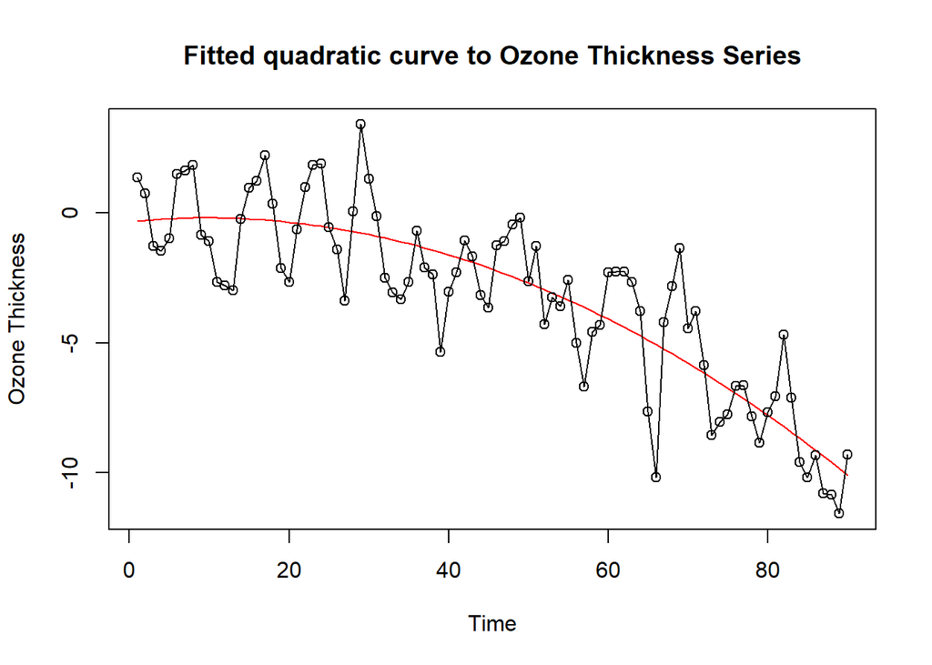

```r
#Plotting the built model
plot(ts(fitted(model_qd)),
     ylim = c(min(c(fitted(model_qd),
     as.vector(ozonethickness))),
     max(c(fitted(model_qd),as.vector(ozonethickness)))),
     ylab='Ozone Thickness',
     main = "Fitted quadratic curve to Ozone Thickness Series",
     col = 'red')
lines(as.vector(ozonethickness), type="o")
```

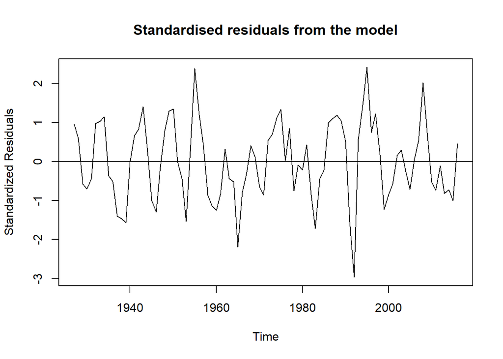

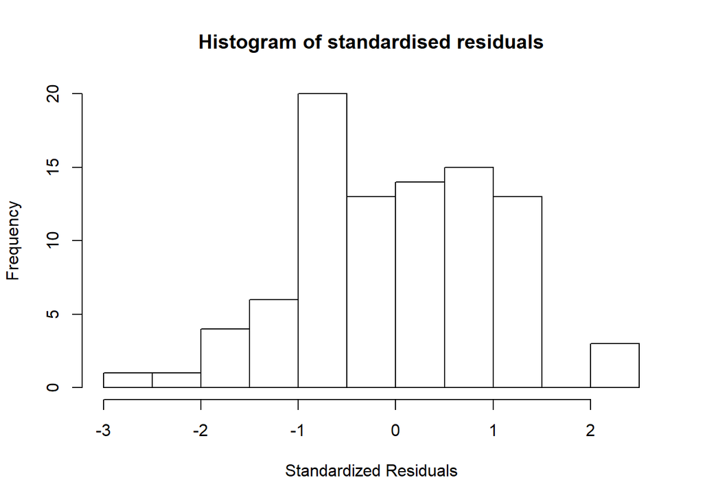

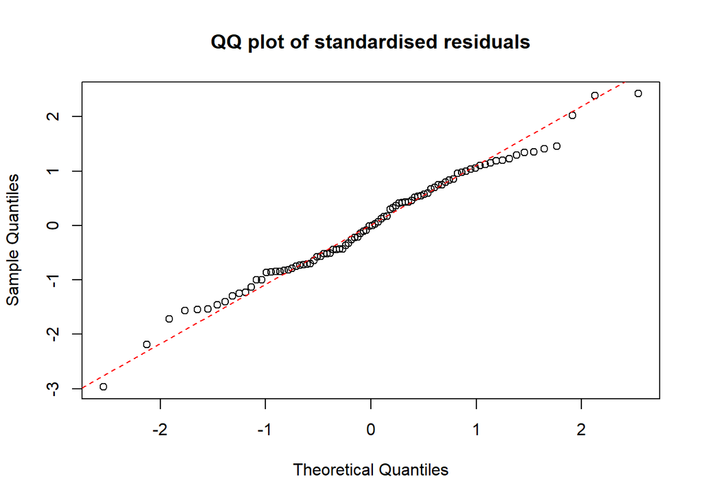

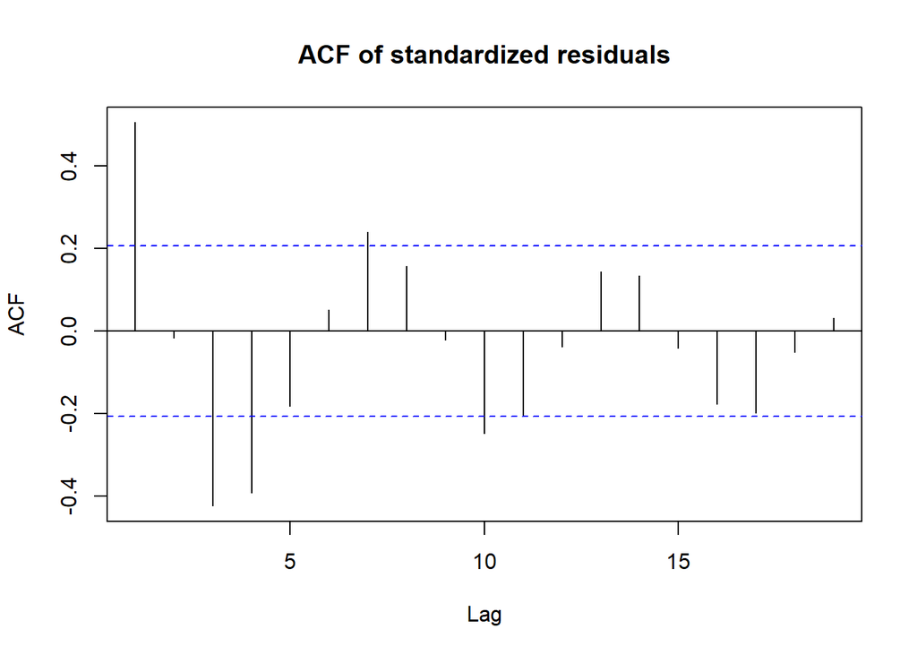

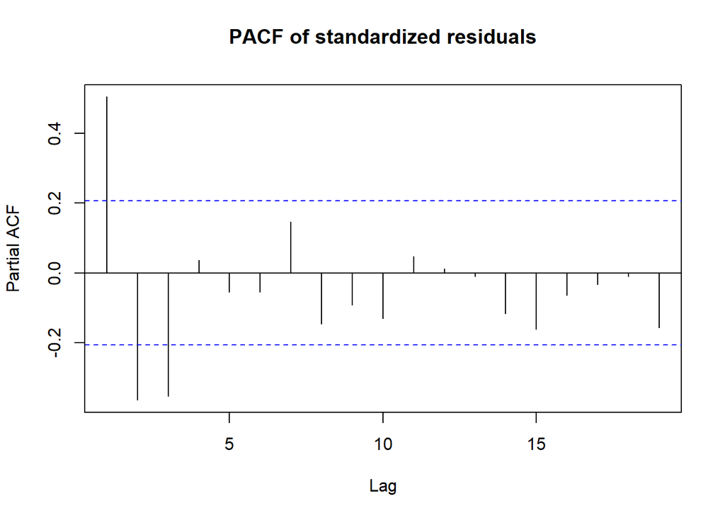

```
## $breaks
##  [1] -3.0 -2.5 -2.0 -1.5 -1.0 -0.5  0.0  0.5  1.0  1.5  2.0  2.5
##
## $counts
##  [1]  1  1  4  6 20 13 14 15 13  0  3
##
## $density
##  [1] 0.02222222 0.02222222 0.08888889 0.13333333 0.44444444 0.28888889
##  [7] 0.31111111 0.33333333 0.28888889 0.00000000 0.06666667
##
## $mids
##  [1] -2.75 -2.25 -1.75 -1.25 -0.75 -0.25  0.25  0.75  1.25  1.75  2.25
##
## $xname
## [1] "res_model_used"
##
## $equidist
## [1] TRUE
##
## attr(,"class")
## [1] "histogram"
```

```r
#Residual Analysis
residual_analysis(model_qd,ozonethickness)
```

## Seasonal and Cyclic Trends

```r
#Selecting the same data in a different dataframe because we want to set a frequency for the cyclic/seasonal model
ozonethickness2 <- ts(as.vector(ozonethickness), start=1927, end=2016, frequency = 2)
month = season(ozonethickness2)
model_cyc = lm(ozonethickness2~month - 1)
summary(model_cyc)
```

```
##
## Call:
## lm(formula = ozonethickness2 ~ month - 1)
##
## Residuals:
##     Min      1Q  Median      3Q     Max
## -8.3605 -1.7335  0.5545  2.3792  6.6261
##
## Coefficients:
##               Estimate Std. Error t value Pr(>|t|)
## monthSeason-1  -3.2189     0.3682  -8.742 1.72e-15 ***
## monthSeason-2  -3.1169     0.3703  -8.418 1.26e-14 ***
## ---
## Signif. codes:  0 '***' 0.001 '**' 0.01 '*' 0.05 '.' 0.1 ' ' 1
##
## Residual standard error: 3.493 on 177 degrees of freedom
## Multiple R-squared:  0.4542, Adjusted R-squared:  0.448
## F-statistic: 73.64 on 2 and 177 DF,  p-value: < 2.2e-16
```

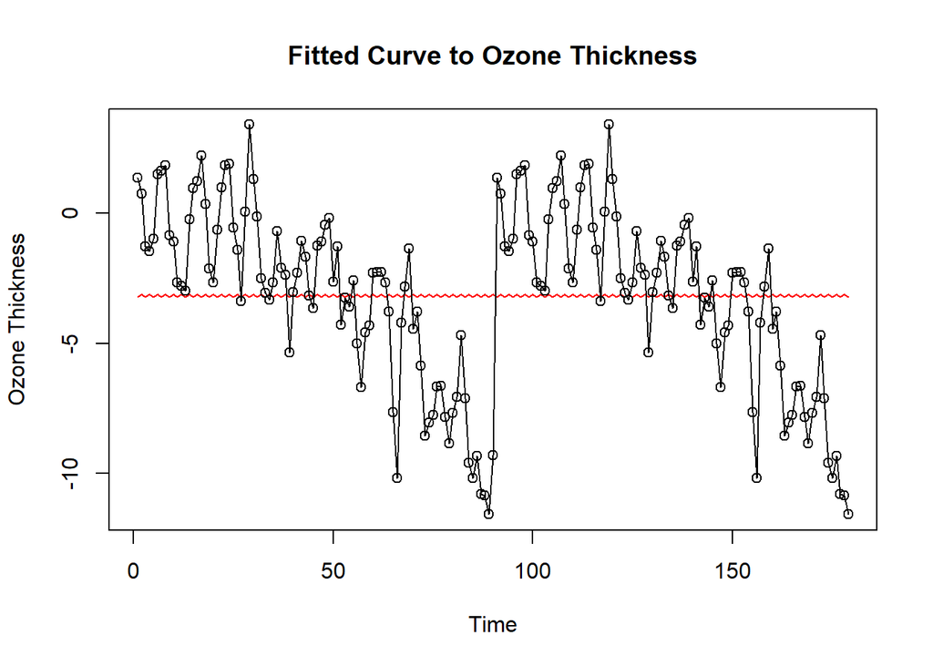

```r
plot(ts(fitted(model_cyc)),
     ylim = c(min(c(fitted(model_cyc), as.vector(ozonethickness2))),
              max(c(fitted(model_cyc),as.vector(ozonethickness2)))),
     ylab='Ozone Thickness',
     main = "Fitted Curve to Ozone Thickness",
     col="red")
lines(as.vector(ozonethickness2),type="o")
```

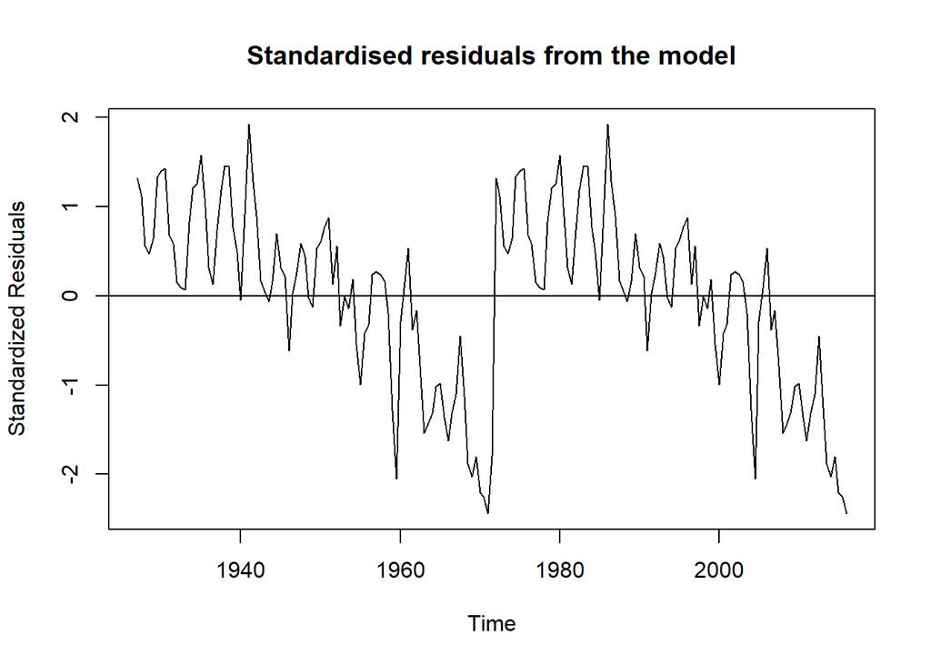

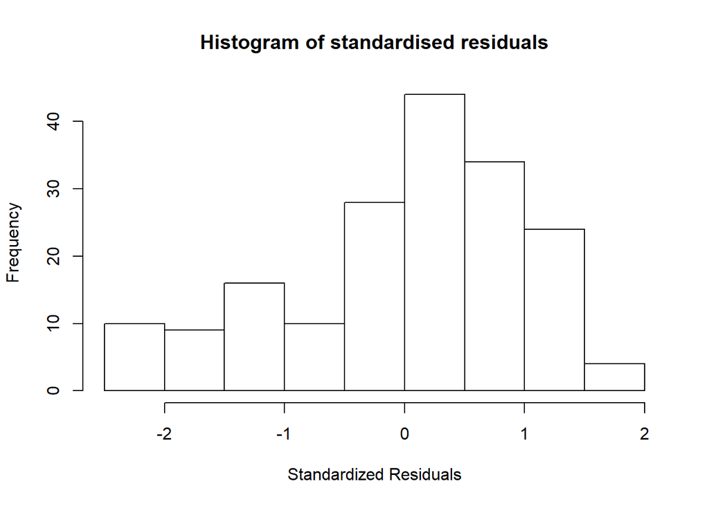

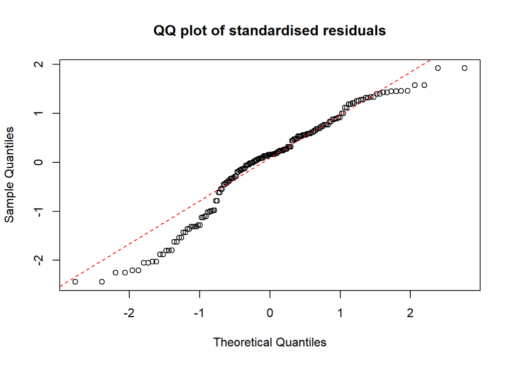

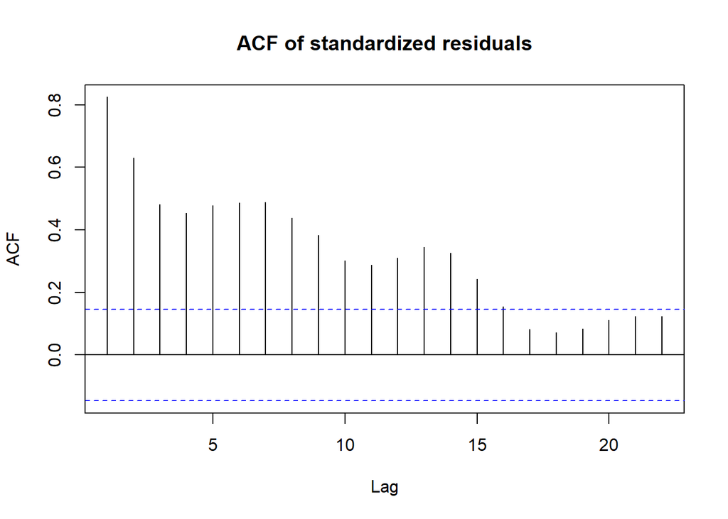

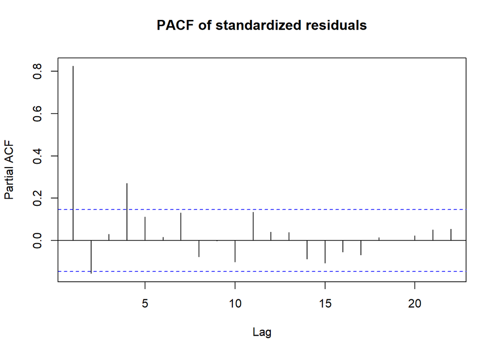

```
## $breaks
##  [1] -2.5 -2.0 -1.5 -1.0 -0.5  0.0  0.5  1.0  1.5  2.0
##
## $counts
## [1] 10  9 16 10 28 44 34 24  4
##
## $density
## [1] 0.11173184 0.10055866 0.17877095 0.11173184 0.31284916 0.49162011 0.37988827
## [8] 0.26815642 0.04469274
##
## $mids
## [1] -2.25 -1.75 -1.25 -0.75 -0.25  0.25  0.75  1.25  1.75
##
## $xname
## [1] "res_model_used"
##
## $equidist
## [1] TRUE
##
## attr(,"class")
## [1] "histogram"
```

```r
residual_analysis(model_cyc,ozonethickness2)
```

We have tryed to fit the time series into a cyclic and seasonal model by setting the frequency 2. The p-value is less than 0.05 significance level. *R-squared value is 0.4542*. The R-squared value is smaller than the quadratic and linear models. The series is not cyclic or seasonal and hence does not fit the cyclic or seasonal model.

## Cosine Trends

```r
har=harmonic(ozonethickness,0.5)
model_cos=lm(ozonethickness~har)
summary(model_cos)
```

```
##
## Call:
## lm(formula = ozonethickness ~ har)
##
## Residuals:
##     Min      1Q  Median      3Q     Max
## -8.3520 -1.8905  0.4837  2.3643  6.4248
##
## Coefficients:
##               Estimate Std. Error t value Pr(>|t|)
## (Intercept) -2.970e+00  4.790e-01  -6.199 1.79e-08 ***
## har          5.462e+11  7.105e+11   0.769    0.444
## ---
## Signif. codes:  0 '***' 0.001 '**' 0.01 '*' 0.05 '.' 0.1 ' ' 1
##
## Residual standard error: 3.522 on 88 degrees of freedom
## Multiple R-squared:  0.006672,   Adjusted R-squared:  -0.004616
## F-statistic: 0.5911 on 1 and 88 DF,  p-value: 0.4441
```

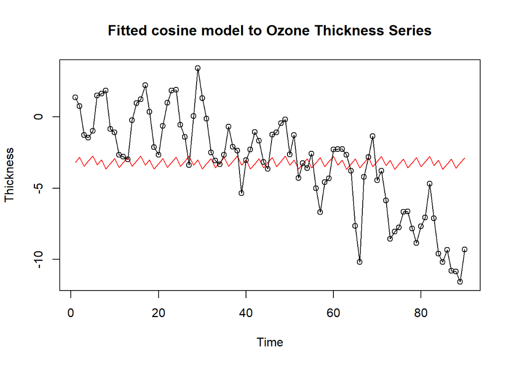

```r
plot(ts(fitted(model_cos)),
     ylab='Thickness',
     type='l',
     ylim=range(c(fitted(model_cos),ozonethickness)),
     main="Fitted cosine model to Ozone Thickness Series",
     col = "red")
lines(as.vector(ozonethickness),type="o")
```

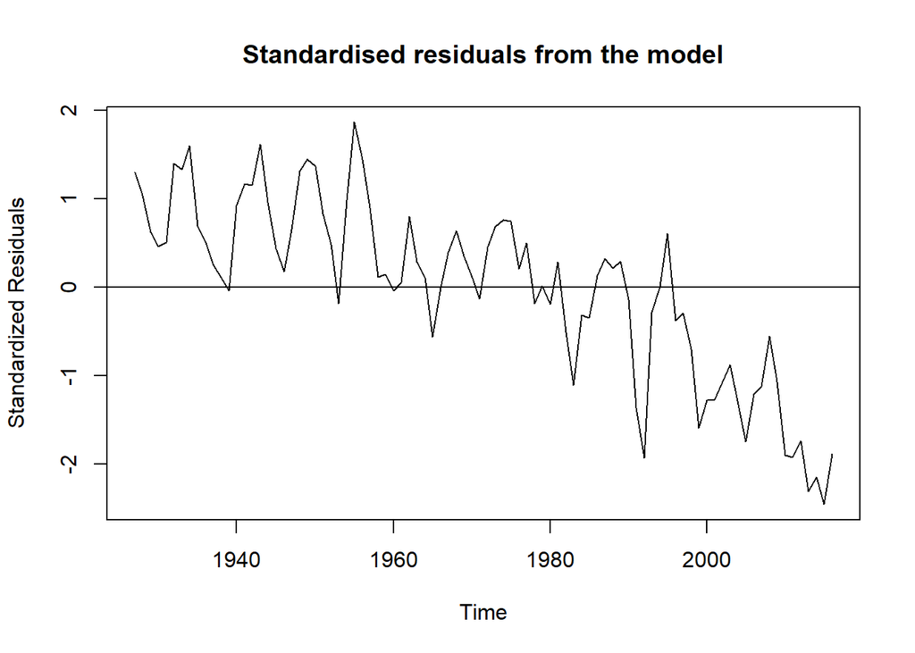

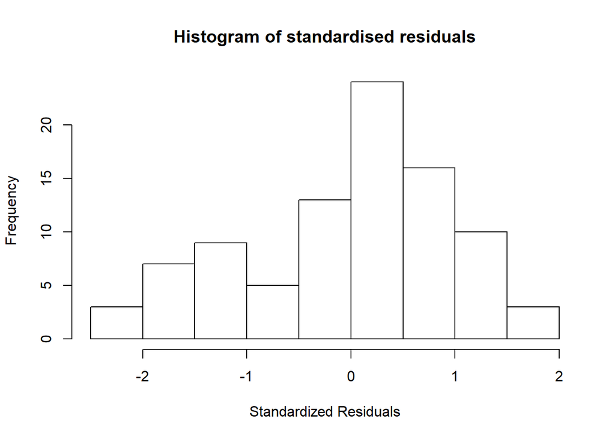

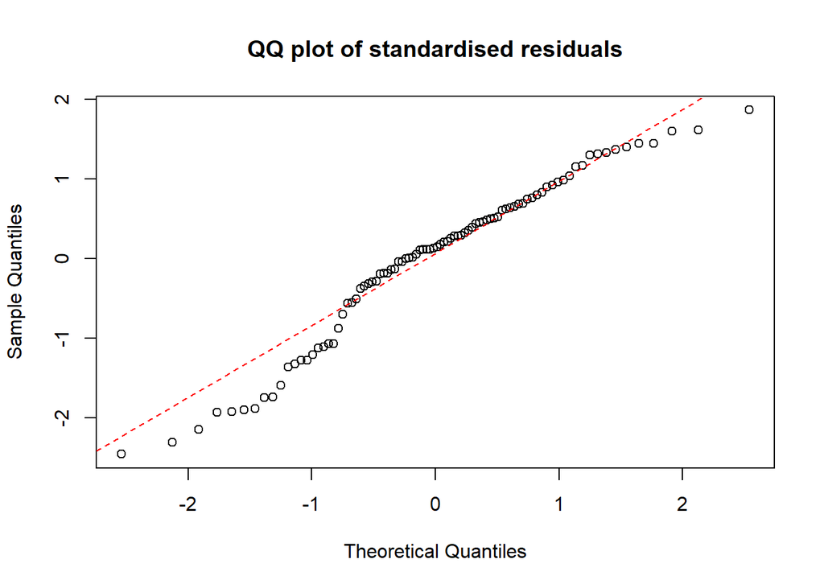

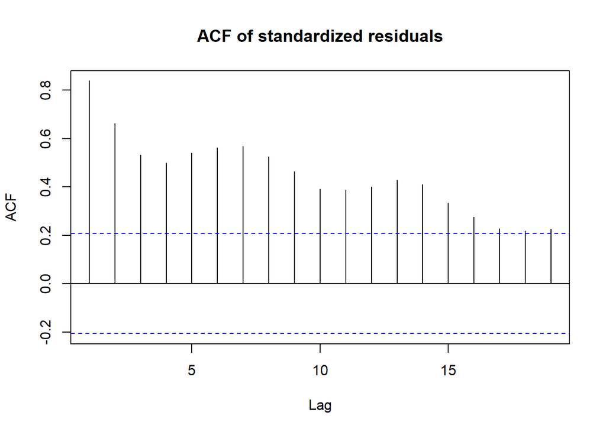

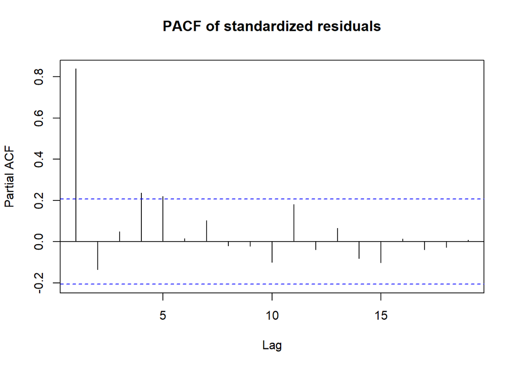

```
## $breaks
##  [1] -2.5 -2.0 -1.5 -1.0 -0.5  0.0  0.5  1.0  1.5  2.0
##
## $counts
## [1]  3  7  9  5 13 24 16 10  3
##
## $density
## [1] 0.06666667 0.15555556 0.20000000 0.11111111 0.28888889 0.53333333 0.35555556
## [8] 0.22222222 0.06666667
##
## $mids
## [1] -2.25 -1.75 -1.25 -0.75 -0.25  0.25  0.75  1.25  1.75
##
## $xname
## [1] "res_model_used"
##
## $equidist
## [1] TRUE
##
## attr(,"class")
## [1] "histogram"
```

```r
residual_analysis(model_cos,ozonethickness)
```

## Forecasting

**The best fitting model obtained is the Quadratic Model** as the R and R-squared values of the Quadratic Model are greater than all the other fitted models.

We will now use the quadratic model and forecast the ozone layer thickness for the next 5 years i.e. 2017 to 2021.

```r
#Creating a time vector for the next five years after 2016
t = c(2017,2018,2019,2020,2021)
t2 = t^2

print(t2)
```

```
## [1] 4068289 4072324 4076361 4080400 4084441
```

```r
#Creating a new data frame with to_forcast and to_forcast2
df_to_forcast = data.frame(t,t2)
forecasts = predict(model_qd, df_to_forcast, interval = "prediction")
print(forecasts)
```

```
##         fit       lwr       upr
## 1 -10.34387 -14.13556 -6.552180
## 2 -10.59469 -14.40282 -6.786548
## 3 -10.84856 -14.67434 -7.022786
## 4 -11.10550 -14.95015 -7.260851
## 5 -11.36550 -15.23030 -7.500701
```

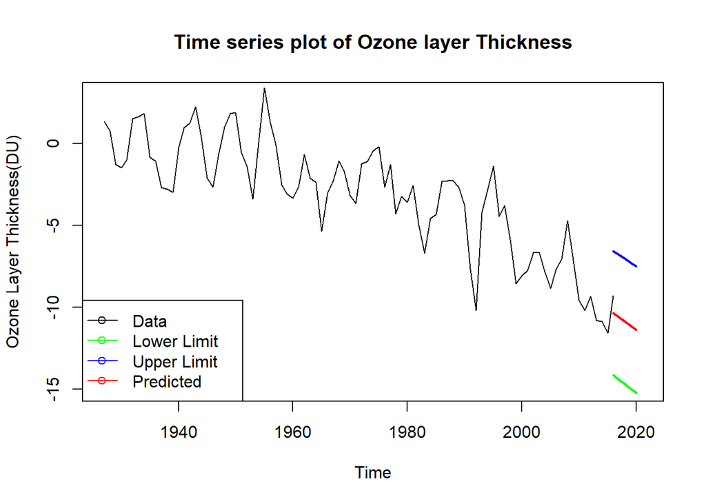

```r
#Plotting the time seties including the predicted 5 years
plot(ozonethickness,
     ylab = "Ozone Layer Thickness(DU)",
     ylim = c(-15,3),
     xlim = c(1927,2021),
     main = "Time series plot of Ozone layer Thickness")

lines(ts(as.vector(forecasts[,1]), start = 2016), col="red", type="l",lwd=2)
lines(ts(as.vector(forecasts[,2]), start = 2016), col="green", type="l",lwd=2)
lines(ts(as.vector(forecasts[,3]), start = 2016), col="blue", type="l",lwd=2)

legend("bottomleft",
       lty=1,
       pch=1,
       col=c("black","green","blue","red"),
       text.width = 18,
       c("Data","Lower Limit","Upper Limit", "Predicted"))
```

We can see that the ozone layer is going to get thinner in the next 5 years as predicted by the data. The predictions can vary between the upper and lower limit i.e. the 5% limit.

# Proposing a set of possible ARIMA(p,d,q) models (Solution of Task 2)

## Plot of the original time series data

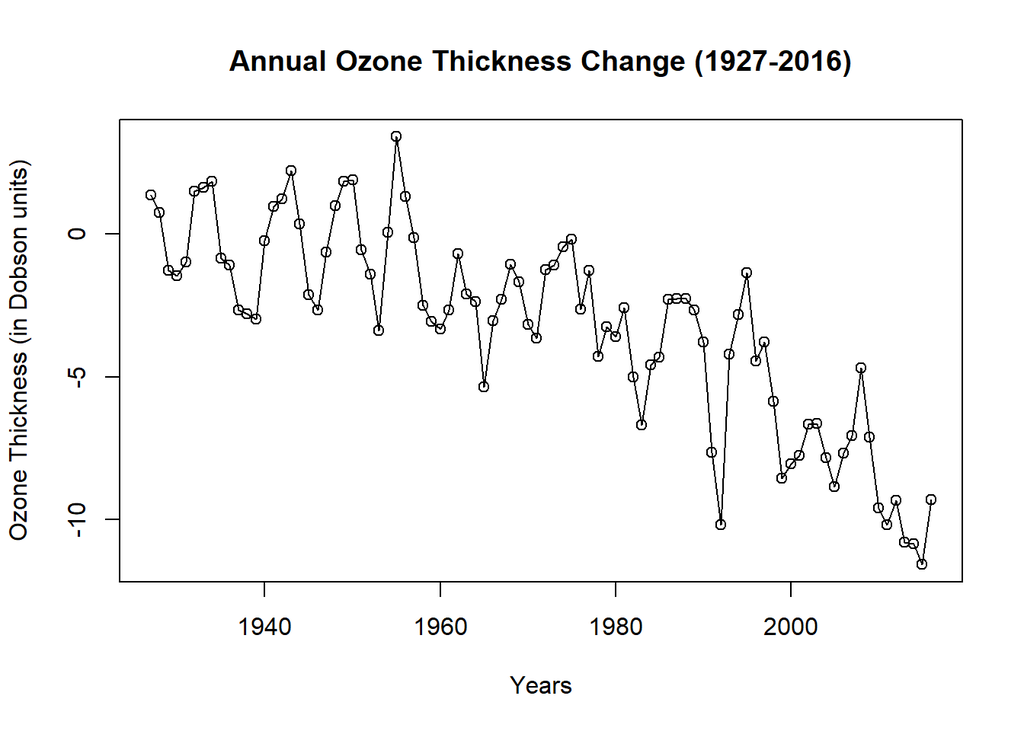

```r
plot(ozonethickness,
     ylab='Ozone Thickness (in Dobson units)',
     xlab='Years',
     type='o',
     main = 'Annual Ozone Thickness Change (1927-2016)')
```

## Plotting the Autocorrelation Function (ACF) and the Partial Autocorrelation Function PACF versus lag

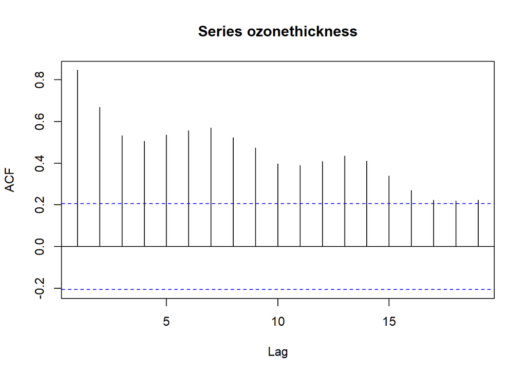

```r
acf(ozonethickness)
```

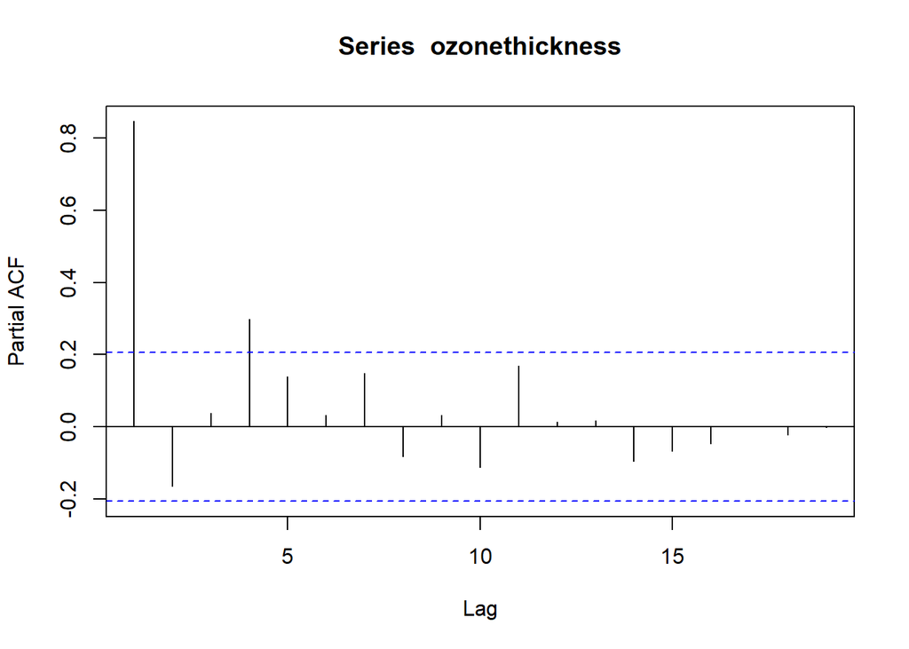

```r
pacf(ozonethickness)
```

The ACF shows a gradual decay in the lags. The PACF has the first high lag value but all the values after that damp down. This is an evidance of non-stationary behaviour and the existance of trend. We will test the data further for the existance of non-stationary behaviour and try to make the time series data stationary.

## Dickey-Fuller Unit Root Test

```r
adf.test(ozonethickness)
```

```
##
##  Augmented Dickey-Fuller Test
##
## data:  ozonethickness
## Dickey-Fuller = -3.2376, Lag order = 4, p-value = 0.0867
## alternative hypothesis: stationary
```

We can observe that the Dicky Fuller test has resulted in a p-value 0.0867 which is greater than 0.05. Hence we fail to reject the null hypothesis that the series is non-stationary.

We have to move forward to Box-Cox and Natural Logarithmic transformations to remove the variance from the data.

## Box-Cox Transformation

We can transform the data into Box-Cox form. However, all the values need to be positive. We have transformed the data by using the following method.

```r
#Add minimum value in the time series data and then add 1
ozonethickness_pos <- ozonethickness + abs(min(ozonethickness))+1
```

[figure not shown]

We will now check the confidence interval and determine the value of lambda.

```r
#Checking the Confidence Interval
ozonethickness_bc_tf$ci
```

```
## [1] 0.9 1.5
```

The confidence interval is 0.9 to 1.5. We can select the intermittent value of lambda = 1.2. We will now transform the time series data using the Box-Cox Transformation with lambda = 1.2

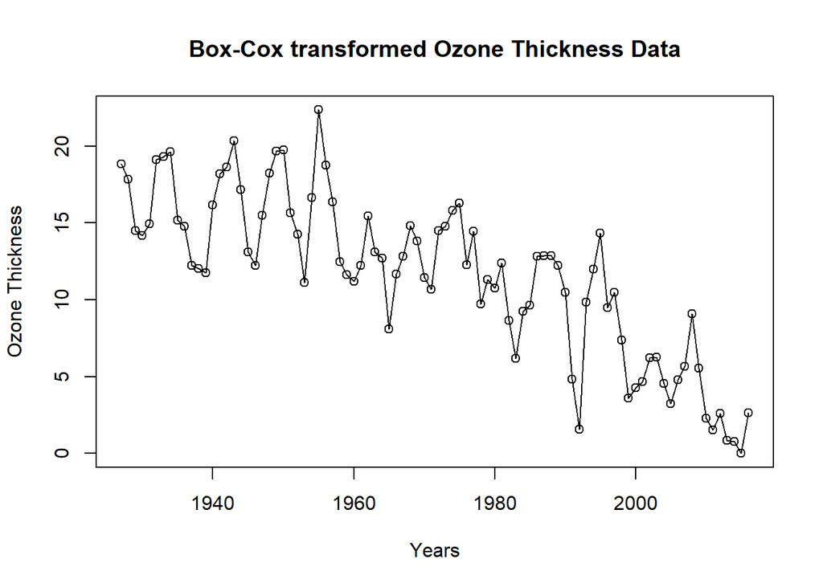

```r
#Transforming the Data
#Setting lambda value to 1.2
lambda = 1.2

# Create Box-Cox transformed data
ozonethickness_bc = (ozonethickness_pos^lambda-1)/lambda

#Plotting the Box-Cox Plot
plot(ozonethickness_bc,
     type='o',
     ylab='Ozone Thickness',
     xlab='Years',
     main='Box-Cox transformed Ozone Thickness Data')
```